# Analisis Data Sakila

Anggita

2026-05-25

# Import Library

```r
library(DBI)
library(RMySQL)
library(dplyr)
library(ggplot2)
library(knitr)
```

# Koneksi Database

```r
con <- dbConnect(
  RMySQL::MySQL(),
  dbname = "sakila",
  host = "localhost",
  port = 3306,
  user = "root",
  password = "Runanjaya.2006"
)
```

# Deskripsi Insight

**Insight yang diambil:** Apakah durasi rental film berpengaruh terhadap jumlah transaksi? Kategori film apa yang paling banyak disewa dan menghasilkan pendapatan terbesar?

## Pengambilan Data

```r
data_sakila <- dbGetQuery(con, "
  SELECT
      c.name            AS category,
      f.title,
      f.rental_duration,
      COUNT(r.rental_id)  AS total_rental,
      SUM(p.amount)       AS total_payment
  FROM film f
  JOIN film_category fc ON f.film_id     = fc.film_id
  JOIN category c       ON fc.category_id = c.category_id
  JOIN inventory i      ON f.film_id     = i.film_id
  JOIN rental r         ON i.inventory_id = r.inventory_id
  JOIN payment p        ON r.rental_id   = p.rental_id
  GROUP BY c.name, f.title, f.rental_duration
  ORDER BY total_rental DESC
")

head(data_sakila)
```

```
##    category              title rental_duration total_rental total_payment
## 1    Travel BUCKET BROTHERHOOD               7           34        180.66
## 2   Foreign   ROCKETEER MOTHER               3           33        116.67
## 3 Animation     JUGGLER HARDLY               4           32         96.68
## 4     Games     FORWARD TEMPLE               6           32        128.68
## 5     Games     GRIT CLOCKWORK               3           32        110.68
## 6     Music      SCALAWAG DUCK               6           32        172.68
```

## Struktur Data

```r
str(data_sakila)
```

```
## 'data.frame':    958 obs. of  5 variables:
##  $ category       : chr  "Travel" "Foreign" "Animation" "Games" ...
##  $ title          : chr  "BUCKET BROTHERHOOD" "ROCKETEER MOTHER" "JUGGLER HARDLY" "FORWARD TEMPLE" ...
##  $ rental_duration: num  7 3 4 6 3 6 3 7 3 3 ...
##  $ total_rental   : num  34 33 32 32 32 32 32 31 31 31 ...
##  $ total_payment  : num  180.7 116.7 96.7 128.7 110.7 ...
```

## Kamus Variabel

| Variabel | Keterangan |
| --- | --- |
| `category` | Kategori/genre film |
| `title` | Judul film |
| `rental_duration` | Lama masa rental (hari) |
| `total_rental` | Jumlah transaksi rental |
| `total_payment` | Total pendapatan (USD) |

# Visualisasi 1 — Kategori Film Terpopuler

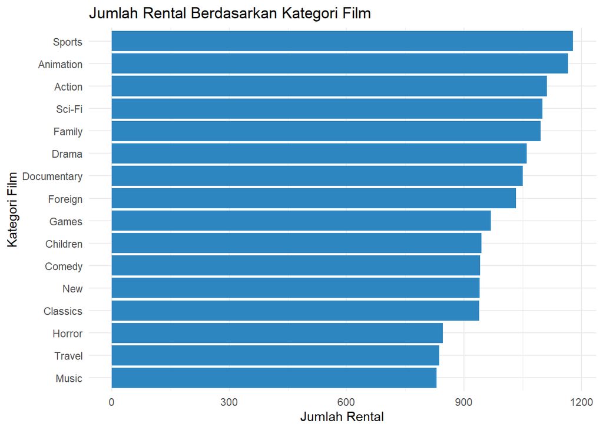

```r
kategori_populer <- data_sakila %>%
  group_by(category) %>%
  summarise(total_rental = sum(total_rental)) %>%
  arrange(desc(total_rental))

ggplot(kategori_populer,
       aes(x = reorder(category, total_rental),
           y = total_rental)) +
  geom_col(fill = "#2e86c1") +
  coord_flip() +
  labs(
    title = "Jumlah Rental Berdasarkan Kategori Film",
    x     = "Kategori Film",
    y     = "Jumlah Rental"
  ) +
  theme_minimal()
```

## Interpretasi

Berdasarkan grafik, kategori **Sports** memiliki jumlah rental tertinggi, diikuti oleh **Animation** dan **Action**. Hal ini menunjukkan bahwa pelanggan lebih banyak menyewa film dengan genre yang menghibur dan dinamis.

**Insight:** Kategori Sports dan Animation dapat dijadikan prioritas dalam strategi penambahan stok film maupun promosi kepada pelanggan.

# Visualisasi 2 — Revenue per Kategori Film

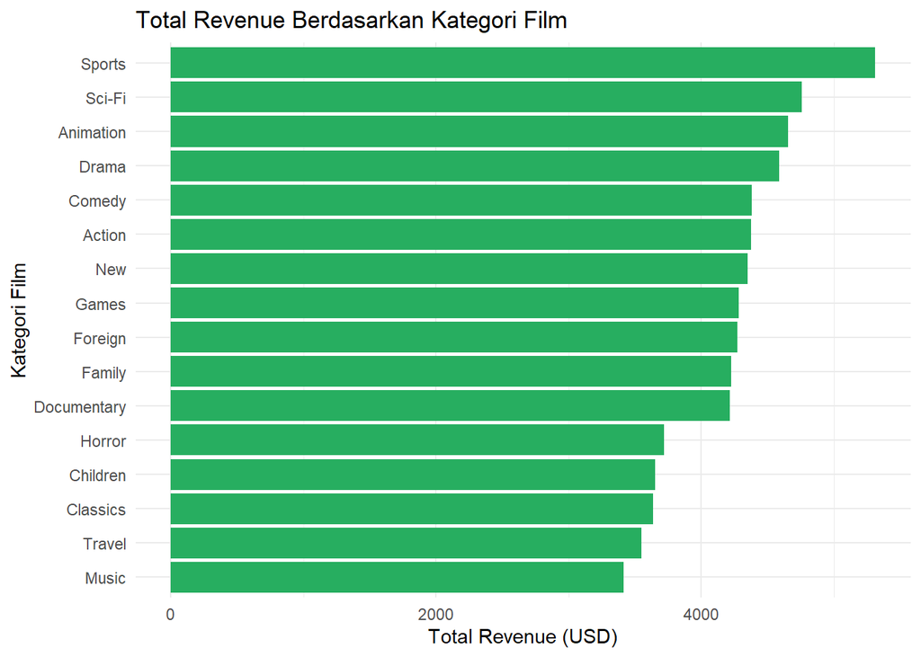

```r
revenue_kategori <- data_sakila %>%
  group_by(category) %>%
  summarise(total_revenue = sum(total_payment)) %>%
  arrange(desc(total_revenue))

ggplot(revenue_kategori,
       aes(x = reorder(category, total_revenue),
           y = total_revenue)) +
  geom_col(fill = "#27ae60") +
  coord_flip() +
  labs(
    title = "Total Revenue Berdasarkan Kategori Film",
    x     = "Kategori Film",
    y     = "Total Revenue (USD)"
  ) +
  theme_minimal()
```

## Interpretasi

Pola revenue secara umum sejalan dengan jumlah rental — kategori yang paling banyak disewa cenderung menghasilkan pendapatan terbesar. Kategori **Sports** kembali berada di posisi teratas, diikuti **Sci-Fi** dan **Animation**.

# Analisis Regresi Linear

## Tujuan

Menguji apakah **durasi rental** (`rental_duration`) berpengaruh terhadap **jumlah transaksi** (`total_rental`).

## Persamaan Model

$$\hat{Y} = \beta_0 + \beta_1 X$$

Keterangan:

- $\hat{Y}$ = prediksi jumlah rental
- $\beta_0$ = intercept
- $\beta_1$ = koefisien slope
- $X$ = rental duration (hari)

## Hasil Model

```r
model  <- lm(total_rental ~ rental_duration, data = data_sakila)
summary(model)
```

```
##
## Call:
## lm(formula = total_rental ~ rental_duration, data = data_sakila)
##
## Residuals:
##     Min      1Q  Median      3Q     Max
## -13.318  -5.318  -0.318   4.841  17.841
##
## Coefficients:
##                 Estimate Std. Error t value Pr(>|t|)
## (Intercept)      18.1872     0.7908  22.998   <2e-16 ***
## rental_duration  -0.2897     0.1531  -1.892   0.0588 .
## ---
## Signif. codes:  0 '***' 0.001 '**' 0.01 '*' 0.05 '.' 0.1 ' ' 1
##
## Residual standard error: 6.667 on 956 degrees of freedom
## Multiple R-squared:  0.003731,   Adjusted R-squared:  0.002689
## F-statistic:  3.58 on 1 and 956 DF,  p-value: 0.05877
```

```r
b0 <- round(coef(model)[1], 2)
b1 <- round(coef(model)[2], 2)
r2 <- round(summary(model)$r.squared, 4)
```

Persamaan regresi yang diperoleh:

$$\hat{Y} = 18.19 + -0.29 \cdot X$$

## Scatter Plot

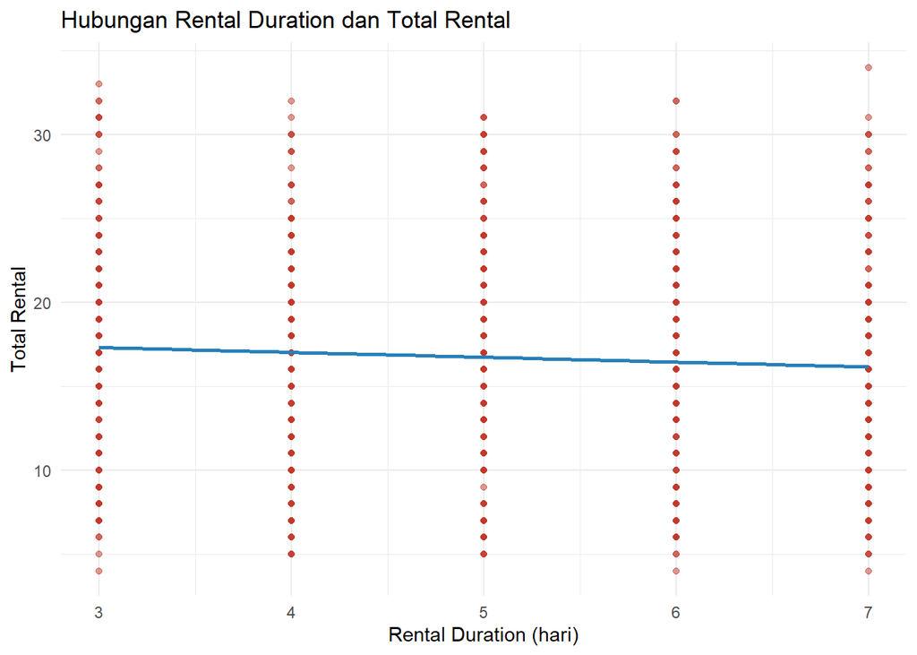

```r
ggplot(data_sakila,
       aes(x = rental_duration, y = total_rental)) +
  geom_point(color = "#c0392b", alpha = 0.5) +
  geom_smooth(method = "lm", se = FALSE, color = "#2980b9") +
  labs(
    title = "Hubungan Rental Duration dan Total Rental",
    x     = "Rental Duration (hari)",
    y     = "Total Rental"
  ) +
  theme_minimal()
```

## Interpretasi

- **Slope ($\beta_1$ = -0.29):** Setiap penambahan 1 hari durasi rental, total rental berubah sebesar -0.29 unit.
- **R² = 0.0037:** Hanya 0.4% variasi total rental yang bisa dijelaskan oleh rental duration. Artinya durasi rental saja tidak cukup kuat untuk memprediksi jumlah transaksi.
- Dari scatter plot terlihat titik-titik data menyebar cukup merata, yang mengonfirmasi bahwa hubungan antara kedua variabel ini lemah.

# Top 10 Pelanggan Paling Aktif

```r
customer <- dbGetQuery(con, "
  SELECT
      CONCAT(c.first_name, ' ', c.last_name) AS customer_name,
      COUNT(r.rental_id)                      AS total_transaksi,
      SUM(p.amount)                           AS total_belanja
  FROM customer c
  JOIN rental r  ON c.customer_id = r.customer_id
  JOIN payment p ON r.rental_id   = p.rental_id
  GROUP BY customer_name
  ORDER BY total_transaksi DESC
  LIMIT 10
")

kable(customer, digits = 2,
      col.names = c("Nama Pelanggan", "Total Transaksi", "Total Belanja (USD)"))
```

| Nama Pelanggan | Total Transaksi | Total Belanja (USD) |
| --- | --- | --- |
| ELEANOR HUNT | 46 | 216.54 |
| KARL SEAL | 45 | 221.55 |
| CLARA SHAW | 42 | 195.58 |
| MARCIA DEAN | 42 | 175.58 |
| TAMMY SANDERS | 41 | 155.59 |
| SUE PETERS | 40 | 154.60 |
| WESLEY BULL | 40 | 177.60 |
| MARION SNYDER | 39 | 194.61 |
| RHONDA KENNEDY | 39 | 194.61 |
| TIM CARY | 39 | 175.61 |

## Interpretasi

Terdapat beberapa pelanggan dengan jumlah transaksi jauh lebih tinggi dibanding rata-rata. Pelanggan seperti ini termasuk segmen **loyal customer** yang potensial untuk diberikan program reward atau membership khusus.

# Kesimpulan

1. Kategori **Sports** dan **Animation** adalah yang paling populer berdasarkan jumlah rental maupun total revenue.
2. **Rental duration tidak berpengaruh signifikan** terhadap jumlah transaksi — nilai R² yang rendah menunjukkan perlu ada variabel prediktor lain.
3. Terdapat sejumlah **pelanggan loyal** dengan aktivitas rental tinggi yang bisa menjadi target program retensi.

# Referensi

1. MySQL Sakila Sample Database — https://dev.mysql.com/doc/sakila/en/
2. Dokumentasi R Markdown — https://rmarkdown.rstudio.com
3. Dokumentasi ggplot2 — https://ggplot2.tidyverse.org